# Human ventromedial prefrontal cortex is necessary for prosocial motivation

Patricia Lockwood & Jo Cutler

2023

# Analysis

## Set up and functions

## Demographics

## Analyse credits earned

### Models of credits

### Post-hoc tests on credits

### Bayesian tests on credits

### Plot credits

## Analyse choice data

### Models of choices

### Format results

### Post-hoc tests on choice data

### Bayesian tests on choices

### Plot choice data

## Computational modelling results

### Plot model comparison

### Plots of model identifiability, parameter recovery & model fit

## Analyse *Κ* parameters

### Bayesian tests on *Κ* parameters

### Plot *Κ* parameters

## Analyse *β* parameters

### Models of *β* parameters

### Bayesian tests on *β* parameters

### Plot *β* parameters

## Analyse success rates

### Models of success rates

### Post-hoc tests on success rates

## Analyse force data

### Models of force data

### Format results

### Post-hoc tests on force data

### Plot force data

## Lesion mapping

### Plot lesion size correlations

### Plot lesion mapping - all patients

### Plot lesion mapping - vmpfc only

# Manuscript

## Methods

### *Participants*

We recruited three groups of participants, one with focal damage to vmPFC and one with lesions elsewhere, from a database of 453 neurological patients, as well as healthy age and gender-matched controls from university databases and the community. The vmPFC lesion group included 25 patients with vmPFC damage (age range=37-76, mean=56.44; 14 females). Two other patients with vmPFC lesions took part but were excluded from all analyses for not following the task instructions or not understanding the task. The lesion control (LC) group included 15 patients with lesions in areas outside vmPFC (age range=28-74, mean=56.00; 10 females). The healthy control (HC) group included 40 participants with no brain damage (age range=36-67, mean=60.00; 23 females), giving a total sample of n=80 for group-based analyses. No statistical methods were used to pre-determine sample sizes but our sample sizes are larger than those reported in previous publications[REFS]. Finally, five additional patients with lesions affecting more dorsal regions of mPFC or the anterior cingulate cortex (ACC) also completed the task (age range=49-66, mean=57.40; 2 females). These patients were only included in the lesion mapping analysis (see below), which had a total sample of 45 patients. We did not include patients with dorsal mPFC or ACC lesions in the between-group analyses, as the damage was not within the vmPFC region of interest, but also was not distinct enough to include in the lesion control group. Results from additional control analyses repeating all the between-group (G)LMMs including these patients in the LC group (n=20) showed the same findings (see column LC n=20 in Tables S2-S7). Classification of lesion location was done from MR imaging or CT scans (see below) by a neurologist (SGM).

Across the vmPFC and LC groups, most lesions were caused by subarachnoid haemorrhage. Three patients’ damage was caused by tumour (2 vmPFC, 1 LC) and one LC patient by head injury. In all cases, the brain damage occurred at least 24 months prior to testing. 15 out of 45 patients were hypertensive (10 vmPFC, 5 LC), four were on antidepressants (1 vmPFC, 3 LC), and 2 took pregabalin (1 vmPFC, 1 LC). We carefully screened participants and recruited them such that there were no differences between groups in terms of gender (*χ*<sup>2</sup><sub>(3)</sub>= 1.17, *p*=0.76), age (*p*s>0.19), self-reported levels of apathy (Apathy Motivation Index[REF]; *p*s>0.14), or performance on a neuropsychological test of cognitive abilities and visual attention (Trail Making Test[REF]; Part A *p*s>0.20, Part B *p*s>0.37). The vmPFC group also did not differ from either control group in self-reported levels of depression (Beck Depression Inventory[REF]; *p*s>0.11) and were matched to lesion controls in the extent of their education (*p*=0.40; Table S1).

## Results

To establish the impact of vmPFC damage on prosocial behaviour, effort, and reward processing, we compared 25 patients with vmPFC damage (mean age=56.44; 14 females) to two control groups. 15 lesion control (LC) patients had damage to areas outside vmPFC (mean age=56.00; 10 females), and 40 healthy control (HC) participants did not have any brain damage (mean age=60.00; 23 females). All participants completed an effort-based decision-making task[REF], that independently manipulated effort, reward, and recipient. Participants chose between a low-effort, low-reward “rest” option and a high-effort high-reward “work” option on each trial. On half of the trials, the reward was for themselves (self) and on the other half, the reward was for an anonymous other person (other; see Methods and Figure 2). The groups were carefully matched, with no differences in gender, age, cognitive ability, or levels of apathy (see Methods and Table S1). The two lesion groups also did not differ from each other in education or depression (see Methods and Table S1). However, the vmPFC and LC groups did differ from healthy controls in level of education. We therefore repeated all our behavioural analysis controlling for education as a covariate. Controlling for education did not change any of our key results or inferences regarding group differences in prosocial behaviour (see Tables S2-S7).

### *Patients with vmPFC damage earn less money for the other person*

Our first analysis examined how many credits participants earned for themselves and the other anonymous participant, which translated into bonus money for each recipient. We tested whether the number of credits earned differed between the three groups (vmPFC, HC, LC) using a generalised linear mixed-effects model (GLMM, see Methods and Table S2). Patients with vmPFC damage earned fewer credits for other relative to self, compared to both control groups (group*recipient interaction vmPFC vs. HC odds ratio<sub>(150)</sub> (OR) [95% confidence interval]=0.88 [0.81, 0.95], *p*=0.003; vmPFC vs. LC OR<sub>(150)</sub>=0.87 [0.78, 0.97], *p*=0.010; Figure 3A). Post-hoc tests revealed that these interactions were driven by the vmPFC group earning significantly fewer credits for the other person, compared to both healthy controls (ratio=0.73, SE=0.07, Z=-3.13, *p*=0.002) and patients with damage elsewhere (ratio=0.76, SE=0.10, Z=-2.18, *p*=0.030). In contrast, vmPFC patients and lesion controls did not statistically differ in the amount they earned for themselves, with Bayesian evidence supporting the null (ratio=1.00, SE=0.13, Z=0.02, *p*=0.99, Bayes factor (BF<sub>01</sub>)=3.05; see Methods). Patients with vmPFC damage also did not significantly differ from healthy controls ratio=0.95, SE=0.09, Z=-0.54, *p*=0.59, BF<sub>01</sub>=2.10). The two control groups did not significantly differ in the number of credits earned for either recipient (other ratio=1.04, SE=0.12, Z=0.31, *p*=0.75, BF<sub>01</sub>=3.17; self ratio=1.06, SE=0.13, Z=0.47, *p*=0.64, BF<sub>01</sub>=2.87). Together, these results show that damage, specifically to vmPFC, decreased rewards earned for the other person.

#### Figure 2

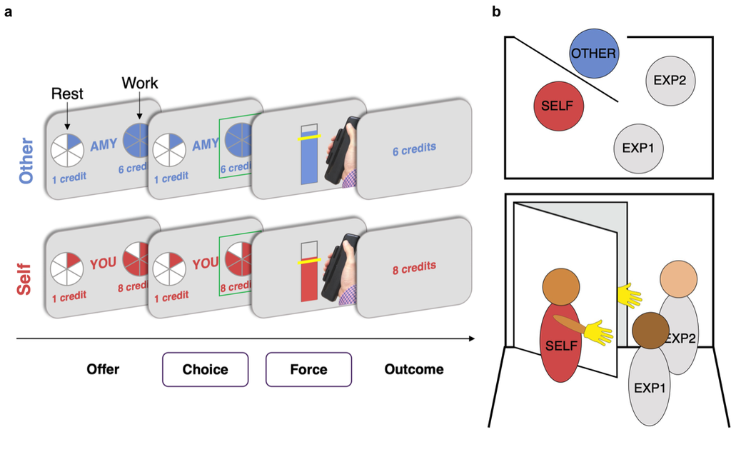

**Figure 2. Effort-based decision-making task with rewards for self or other. (a)** Before any further instructions, participants squeezed as hard as they could to measure their maximum voluntary contraction (MVC) on a handheld dynamometer to threshold each effort level to their strength. After thresholding and practice, participants chose on each trial between a “rest” option, which required no effort (0% MVC, one segment of the pie chart) for a low reward of 1 credit, and a “work” option, which required more effort (30%–70% MVC, 2–6 pie chart segments) and gained more reward (2–10 credits). The reward available and effort required were manipulated independently. After making their choice, participants had to exert the required force (shown by the yellow line) for at least 1s of a 3s window to receive the reward. Visual feedback on the amount of force used was displayed on the screen. Participants then saw the outcome, depending on the offer they had chosen and whether they were successful. If they did not meet the required force level, “0 credits” was displayed. Crucially, on self-trials, participants made the choice, exerted the effort, and received the reward themselves, whereas on other trials (“AMY” in this example), participants made the choice and exerted the effort, but the other participant received the reward. **(b)** Participants were designated as “Player 1” (self) and told that their decisions impacted another player “Player 2” (other) whom they met at the beginning of the testing session with their identity obscured (to control for influences of identity or reciprocity). The name used in the task was gender-matched to the participant. The procedure involved 4 people, two experimenters, EXP1 and EXP2, and two participants, self and other.

### *Damage to vmPFC decreases prosocial behaviour*

To examine what was driving the group difference in the broad measure of credits earned, we first considered participants’ willingness to choose the high-effort work option over rest. Using a binomial GLMM (see Methods), we tested whether vmPFC lesions affected prosociality (recipient*group interaction) in choices. Analysing choices on each trial also enabled us to test group differences in sensitivity to rewards (reward level 2-6: 2, 4, 6, 8 or 10 credits) and effort (effort level 2-6: 30, 40, 50, 60 or 70% of maximum, squared to match computational model; see Methods). We also considered the possibility of higher-order interactions by starting with a maximal model containing fixed effects of and all interactions (up to 4-way) between effort, reward, recipient, and group, as well as random effects and all interactions (up to 3-way) between effort, reward, and recipient. Data-driven model reduction suggested that no interaction terms between more than two variables significantly improved the model (see Methods).

Prosociality decreased with vmPFC damage (Table S3). vmPFC patients chose to work to benefit the other person less than both control groups (vmPFC vs. HC OR=0.33, SE=0.17, Z=-2.11, *p*=0.034; vmPFC vs. LC OR=0.23, SE=0.15, Z=-2.19, *p*=0.029; Figure 3B). In contrast, the vmPFC group was equally willing to exert effort to benefit themselves compared to both control groups (vmPFC vs. HC OR=0.91, SE=0.51, Z=-0.17, *p*=0.87, BF<sub>01</sub>=3.57; vmPFC vs. LC OR=1.01, SE=0.72, Z=0.01, *p*=0.99, BF<sub>01</sub>=3.13). Finally, the two control groups did not significantly differ in willingness to exert effort for self or other, although these contrasts were not sensitive enough to support evidence of no difference (self OR=1.11, SE=0.73, Z=0.16, *p*=0.88, BF<sub>01</sub>=2.95; other OR=0.70, SE=0.43, Z=-0.58, *p*=0.56, BF<sub>01</sub>=2.56).

#### Figure 3

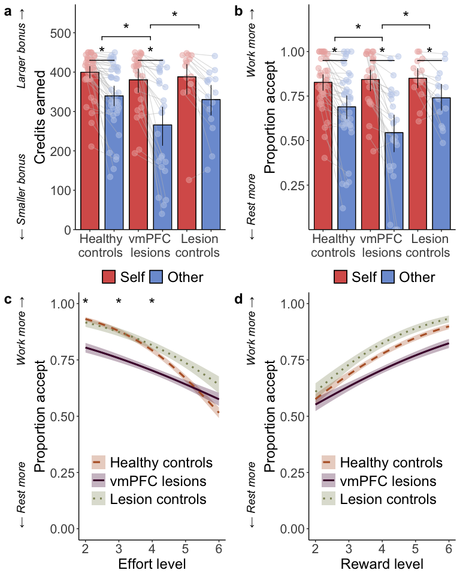

### *vmPFC lesions decrease effort sensitivity*

Analysis of sensitivity to reward showed participants in all three groups chose to work more when a larger reward was available (vmPFC GLMM OR=6.91 [4.70, 10.15], *p*<0.001; Figure 3D)), particularly when the reward was for themselves compared to another person (recipient*reward interaction OR=1.71 [1.46, 2.01], *p*<0.001). However, there was no evidence of group differences in reward processing (Figure 3D). The group*reward interaction was not selected as a term in the GLMM and there was strong evidence against adding it to the best-fitting model (Δ deviance *χ*<sup>2</sup><sub>(2)</sub>=2.74, *p*=0.25, Δ BIC=15.98, BF<sub>01</sub>=2950.76).

### *Reward devaluation by effort depends on recipient*

So far, we have shown vmPFC damage has a detrimental impact on prosocial decision-making, and that this is at least partially due to vmPFC patients’ lower willingness to exert prosocial effort, compared to both control groups. Next, we fitted computational models of effort-discounting to participants’ choice behaviour to precisely quantify how the effort required was integrated with the reward available to determine choices for self or other. Importantly, these models separate the extent to which effort devalues the reward (discounting *Κ* parameter) from choice consistency (inverse stochasticity *β* parameter) and therefore allow us to test which of these parameters differ between recipients and groups.

We fit and compared multiple models to participants’ choice behaviour using a hierarchical expectation maximisation approach… [paragraph only in word doc for refs]. The robustness of the model comparison procedure and winning model was established using simulated data (see Methods). Model identifiability results demonstrated perfect identifiability (Figure 4A). The simulations also showed very good recovery of all parameters in the 2*Κ*2*β* winning model (*Κ*<sub>self</sub>=0.87, *Κ*<sub>other</sub>=0.87, *β*<sub>self</sub>=0.86, *β*<sub>other</sub>=0.86).

#### Figure 4

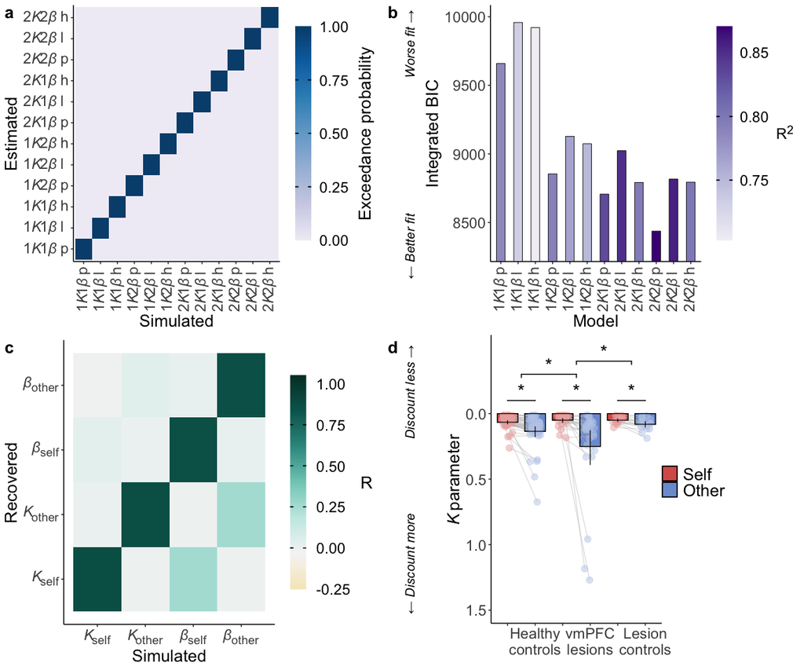

**Figure 4. A computational neurology approach reveals vmPFC damage increases discounting of rewards for other by effort. (a)** Results of model identifiability analysis show a strong diagonal across the average exceedance probability confusion matrix, meaning the models of interest can be accurately identified. We simulated ten datasets each with 100 artificial agents, using each of the 12 models. Parameters were drawn at random from a flat distribution between the upper and lower bounds used when fitting the model to participant data (0<*Κ*<1.5, 0<*β*<4). We then fit each dataset using the same model fitting and comparison procedure applied to participant data and plotted the confusion matrix from the exceedance probability averaged across the ten runs. **(b)** Model comparison of the 12 candidate models shows the 2*Κ*2*β* parabolic model best fits the participant data based on multiple fit metrics. This model had a parabolic discounting function and contained separate discounting and choice stochasticity parameters for self and other. It had the highest exceedance probability (XP=1), lowest integrated BIC, and explained the highest proportion of variance in choices (R<sup>2</sup>=0.87). **(c)** Strong parameter recovery for the 2*Κ*2*β* is shown by the high correlations on the diagonal between simulated and recovered parameter values and low off-diagonal correlations. Simulations for parameter recovery used a grid of values for *Κ* (0, 0.3, 0.6, 0.9, 1.2, 1.5) and *β* (0, 1, 2, 3, 4), with added noise drawn from a normal distribution * 0.05, to cover the full range of possible values. **(d)** Comparing discounting (*Κ*) parameters from the winning model between recipients and groups shows vmPFC damage increases discounting of prosocial rewards. Asterisks between groups represent significant interactions between the recipient (self or other) and group in the GLMM. Asterisks between self and other represent significant differences within each group in post-hoc comparisons (*p*<0.05 uncorrected: follow-ups of significant GLMM interactions).

### *vmPFC lesions increase the discounting of prosocial rewards by effort*

After establishing the 2*Κ*2*β* model was robust and best fit the data, we assessed whether the *Κ* parameters differed between groups with a GLMM (see Methods). Damage to vmPFC decreased prosociality compared to both control groups (group*recipient interaction vmPFC vs. LC OR=1.46 [1.15, 1.85], *p*=0.002; vmPFC vs. HC OR=1.36 [1.12, 1.65], *p*=0.002; Figure 4D & Table S4). Patients with vmPFC lesions specifically increased how much rewards for another person were discounted, whereas effort discounting for self was the same regardless of lesion location (vmPFC vs. LC: other ratio=2.18, SE=0.73, Z=2.31, *p*=0.021; self ratio=1.02, SE=0.34, Z=0.07, *p*=0.94, BF<sub>01</sub>=3.16). In contrast, levels of prosociality did not differ between the two control groups (post-hoc group*recipient interaction=0.87, SE=0.19, Z=-0.65, *p*=0.52) further supporting the specificity of vmPFC damage. Finally, all groups showed higher effort discounting of rewards for other compared to self (Figure 4D) indicating that the bias towards helping oneself, occurs across healthy controls and patients, regardless of lesion location.

We used the same approach to examine whether vmPFC damage affected decision consistency (inverse stochasticity *β* parameter). Across all groups, participants made less consistent decisions in the prosocial compared to the self-benefiting condition (*p*s<0.007; Figure S1). However, there was no evidence this self vs. other difference was significantly affected by vmPFC damage (LMM group*recipient interactions *p*s>0.18) or that overall levels of decision noise differed between groups *p*s>0.12; Table S5).

### *Patients with vmPFC damage exert less force to help another person*

Decreased prosocial decisions in vmPFC patients at least partially explain why this group earned fewer credits for the other person than both control groups. Our final behavioural analysis considered how much force participants exerted after choosing to exert effort for themselves or for the other person. As with the choice data, we modelled force (normalised area under the curve, see Methods) by reducing a maximal LMM that contained fixed effects and all interactions (up to 4-way) between effort, reward, recipient, and group, as well as random effects and all interactions (up to 3-way) between effort, reward, and recipient (see Table S6 for full results).

Patients with vmPFC damage exerted less force for the other person relative to self overall, compared to healthy controls (group*recipient interaction b<sub>(8638)</sub>=-0.092 [-0.178, -0.006], *p*=0.036; Figure 5), particularly at higher effort levels (group*recipient*effort interaction b<sub>(8638)</sub>=-0.027 [-0.052, -0.002], *p*=0.037) and when the reward available was lower (group*recipient*effort*reward interaction b<sub>(8638)</sub>=0.052 [0.028, 0.076], *p*<0.001; Figure S2). Lower exerted force for others is consistent with vmPFC patients exhibiting ‘superficial prosociality’, sometimes deciding to benefit another person but then not energising actions enough to do so. The finding that sensitivity to effort and reward were important in determining the force exerted is also evidence against the idea that vmPFC damage led to inattention to the details of the work offer.

Next, we directly compared success rates between the two groups to test whether under-exertion of force on prosocial trials led to less reward being delivered to the other person, rather than an over-energisation of action for self. We ran an LMM predicting average success rates in each group for self and other (Table S7). Interestingly, results revealed that patients with vmPFC successfully exerted the required effort more often for self (95.05% success rate) than other (87.29%; contrast=0.08, SE=0.02, t=3.17, *p*=0.002). In contrast, healthy control participants had similar success rates for self (97.57%) and other (96.91%; contrast=0.01, SE=0.02, t=0.35, *p*=0.73, BF<sub>01</sub>=2.95; LMM group*recipient interaction b<sub>(150)</sub>=-0.319 [-0.592, -0.045], *p*=0.023). The high success rate vmPFC patients had when rewards were for themselves (95.05%) shows that they were perfectly capable of energising actions, suggesting a lack of prosocial motivation caused higher rates of failure for other.

#### Figure 5

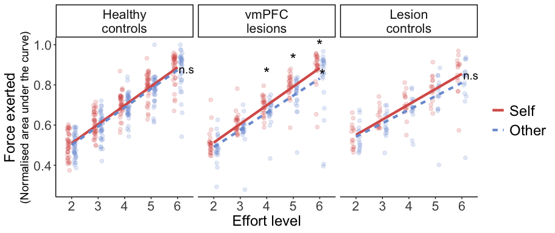

**Figure 5. Patients with vmPFC lesions exert less force for other relative to self, particularly when a large amount of effort is required.** Patients with vmPFC damage exerted less force to obtain reward for the other person than themselves (post-hoc contrast=0.04, SE=0.01, Z=3.62, *p*<0.001), whereas this was not the case for healthy control participants (post-hoc contrast=0.01, SE=0.01, Z=1.32, *p*=0.19; LMM group*recipient interaction b<sub>(8638)</sub>=-0.09 [-0.18, -0.01], *p*=0.036) or lesion control patients (post-hoc contrast=0.02, SE=0.01, Z=1.70, *p*=0.088; LMM group*recipient interaction b<sub>(8638)</sub>=-0.05 [-0.16, 0.05], *p*=0.33). The difference between vmPFC patients and healthy controls in energising actions to benefit other, relative to self, was particularly large when the level of effort required was greatest (LMM group*recipient*effort interaction b<sub>(8638)</sub>=-0.03 [-0.05, 0.00], *p*=0.037) and also when the reward available was smallest (LMM group*recipient*effort*reward interaction b<sub>(8638)</sub>=0.05 [0.03, 0.08], *p*<0.001; Figure S2). These interactions were not significant when comparing vmPFC and lesion control groups (Table S6). Asterisk or not significant (n.s) at the end of lines represent recipient*effort interactions in each group. Asterisks above lines represent significant differences in post-hoc comparisons at each effort level (*p*<0.05 uncorrected: follow-ups of significant GLMM interactions).

In summary, multiple behavioural measures and computational parameters revealed that damage to vmPFC specifically reduced willingness to exert effort to help another person, compared to controls both with and without lesions. Lesions to vmPFC also led to a lower willingness to energise actions, even after deciding to help others.

### *Damage to medial vmPFC is associated with decreased willingness to help others whereas lateral vmPFC damage increases prosociality*

[Lesion mapping results only in word]

#### Figure 6

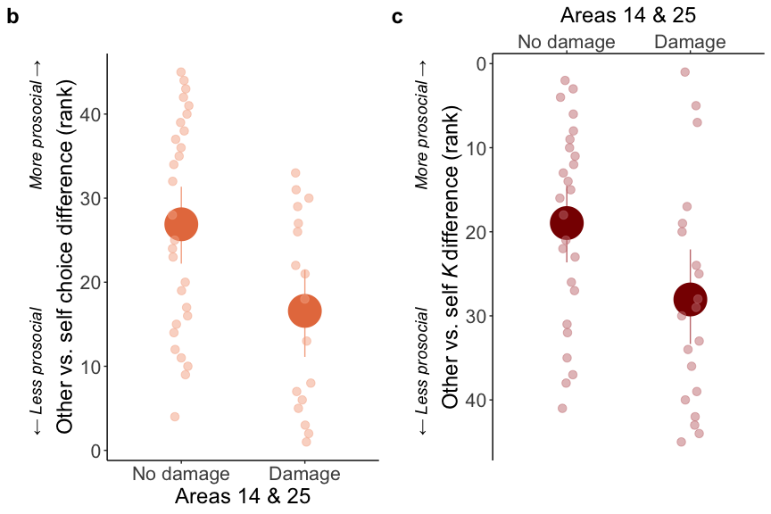

#### Figure 7

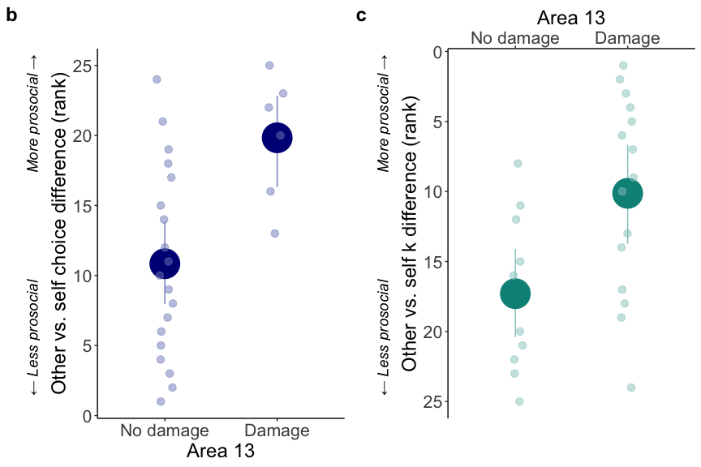

# Supplement

#### Figure S1

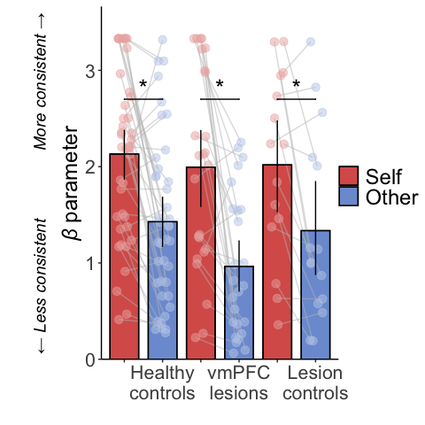

#### Figure S2

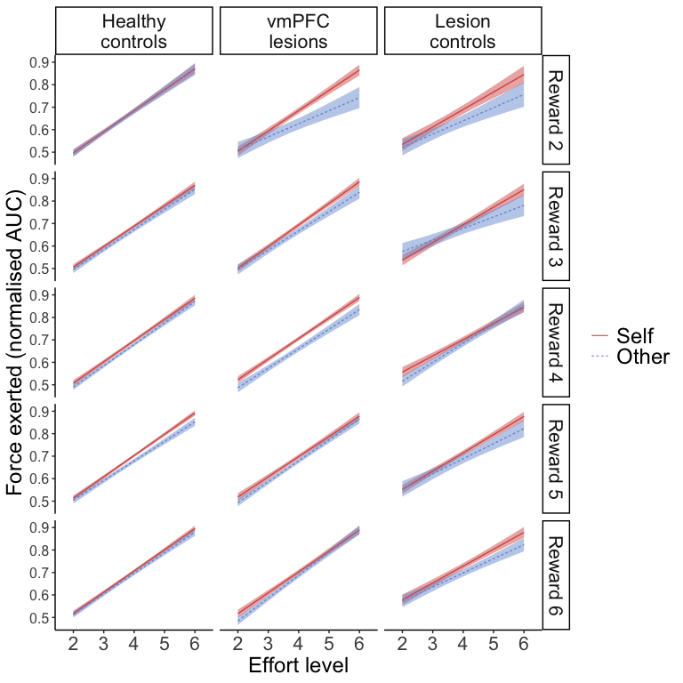

#### Figure S3

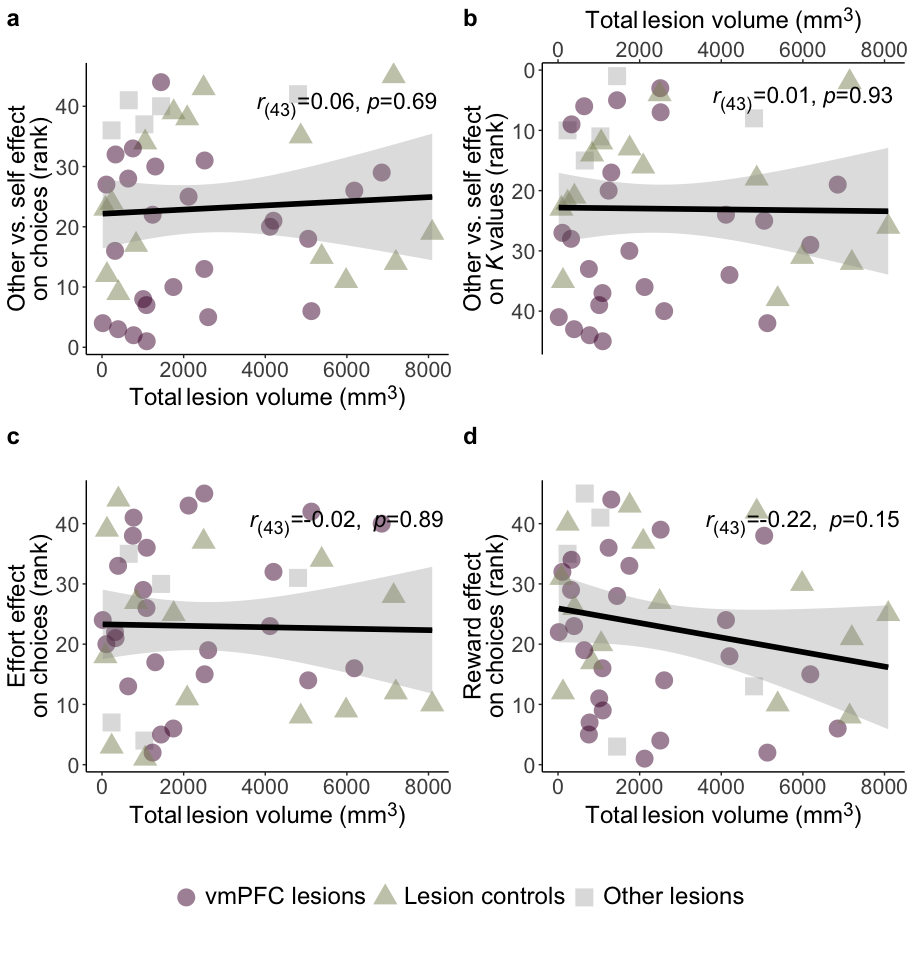

**Figure S3. No significant correlations between total lesion size and the behavioural predictors for VLSM.** As a control analysis to support the voxel-based lesion symptom mapping (VLSM), we correlated total lesion volume with each of the four behavioural predictors, calculated as the (ranked) participant-level random effects from the generalised linear mixed-effects models of choices and *Κ* parameters (effect of recipient on choices, effect of reward on choices, effect of effort on choices, effect of recipient on *Κ* parameters). The lack of significant correlations in all cases suggests that overall lesion size did not confound the VLSM analysis and results are specific to damage in each of the identified subregions.

#### Figure S6

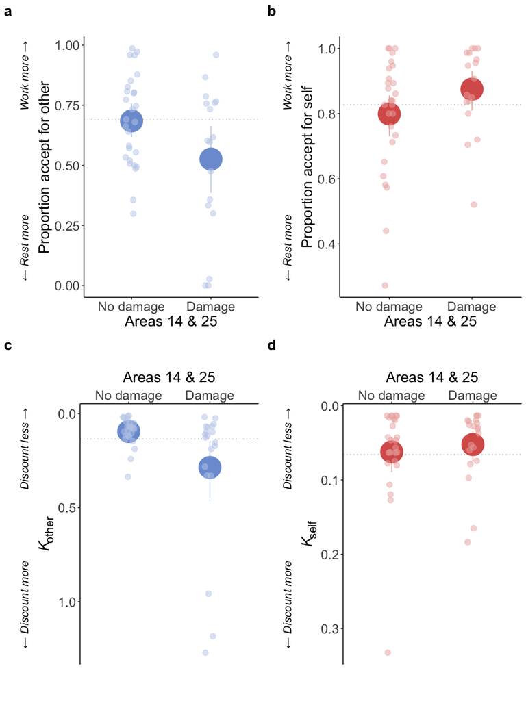

#### Figure S7

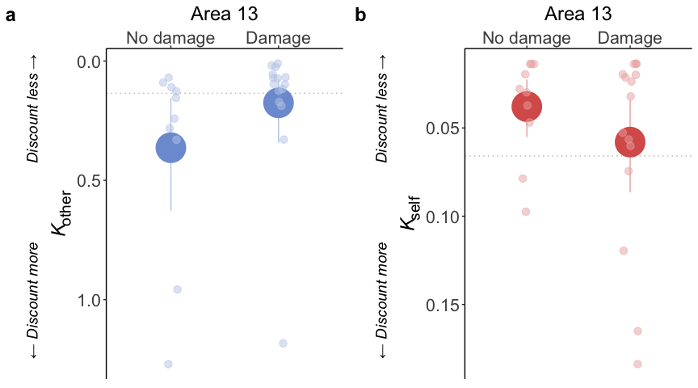

#### Table S1

Summary of demographic variables for each group

| measure | HC | SD HC | vmPFC | SD vmPFC | LC | SD LC | hc vs. vmPFC | lc vs. vmPFC | hc vs. lc |
| --- | --- | --- | --- | --- | --- | --- | --- | --- | --- |
| Age | 60.00 | 8.11 | 56.44 | 10.95 | 56.00 | 11.81 | 0.19 | 0.99 | 0.20 |
| Gender | 0.42 | 0.50 | 0.44 | 0.51 | 0.33 | 0.49 | 0.91 | 0.52 | 0.55 |
| Qualification | 4.08 | 1.14 | 2.84 | 1.11 | 3.27 | 1.33 | <0.001 | 0.40 | 0.034 |
| AMI tot | 1.19 | 0.50 | 1.41 | 0.57 | 1.32 | 0.60 | 0.14 | 0.99 | 0.30 |
| BDI | 7.75 | 9.34 | 10.52 | 8.27 | 14.27 | 11.54 | 0.11 | 0.36 | 0.044 |
| Trail A | 23.37 | 8.16 | 26.28 | 9.50 | 29.24 | 13.64 | 0.20 | 0.65 | 0.16 |
| Trail B | 57.17 | 29.76 | 66.90 | 41.15 | 75.32 | 37.25 | 0.40 | 0.37 | 0.081 |

#### Table S2

Generalised linear mixed-effects model predicting credits

| Parameter | Coefficient | SE | CI_low | CI_high | t | p |
| --- | --- | --- | --- | --- | --- | --- |
| (Intercept) | 299.50 | 21.23 | 260.36 | 344.53 | 80.44 | <0.001 |
| Recipient (Self vs. Other) | 1.25 | 0.04 | 1.17 | 1.33 | 6.59 | <0.001 |
| Group (vmPFC vs. HC) | 1.20 | 0.11 | 1.01 | 1.44 | 2.03 | 0.044 |
| Group (vmPFC vs. LC) | 1.15 | 0.13 | 0.91 | 1.44 | 1.19 | 0.23 |
| Recipient (Self vs. Other) * Group (vmPFC vs. HC) | 0.88 | 0.04 | 0.81 | 0.95 | -3.07 | 0.003 |
| Recipient (Self vs. Other) * Group (vmPFC vs. LC) | 0.87 | 0.05 | 0.78 | 0.97 | -2.60 | 0.010 |

#### Table S3

Generalised linear mixed-effects model predicting choices

| Parameter | Coefficient | SE | CI_low | CI_high | z | p |
| --- | --- | --- | --- | --- | --- | --- |
| (Intercept) | 14.25 | 6.10 | 6.16 | 32.95 | 6.21 | <0.001 |
| Effort | 0.40 | 0.08 | 0.27 | 0.60 | -4.43 | <0.001 |
| Reward | 6.91 | 1.36 | 4.70 | 10.15 | 9.83 | <0.001 |
| Recipient (Self vs. Other) | 5.73 | 1.22 | 3.77 | 8.70 | 8.18 | <0.001 |
| Group (vmPFC vs. HC) | 1.83 | 0.90 | 0.70 | 4.82 | 1.23 | 0.22 |
| Group (vmPFC vs. LC) | 2.09 | 1.32 | 0.60 | 7.21 | 1.16 | 0.25 |
| Effort * Group (vmPFC vs. HC) | 0.44 | 0.10 | 0.28 | 0.69 | -3.57 | <0.001 |
| Effort * Group (vmPFC vs. LC) | 0.73 | 0.21 | 0.42 | 1.27 | -1.11 | 0.27 |
| Reward * Recipient (Self vs. Other) | 1.71 | 0.14 | 1.46 | 2.01 | 6.56 | <0.001 |
| Recipient (Self vs. Other) * Group (vmPFC vs. HC) | 0.60 | 0.14 | 0.38 | 0.94 | -2.22 | 0.026 |
| Recipient (Self vs. Other) * Group (vmPFC vs. LC) | 0.48 | 0.14 | 0.27 | 0.84 | -2.57 | 0.010 |
| Effort * Reward | 0.93 | 0.06 | 0.82 | 1.06 | -1.06 | 0.29 |

#### Table S4

Generalised linear mixed-effects model predicting *Κ* parameter

| Parameter | Coefficient | SE | CI_low | CI_high | t | p |
| --- | --- | --- | --- | --- | --- | --- |
| (Intercept) | 0.08 | 0.02 | 0.05 | 0.12 | -13.18 | <0.001 |
| Recipient (Self vs. Other) | 0.54 | 0.04 | 0.46 | 0.64 | -7.71 | <0.001 |
| Group (vmPFC vs. HC) | 0.84 | 0.21 | 0.52 | 1.36 | -0.72 | 0.47 |
| Group (vmPFC vs. LC) | 0.67 | 0.21 | 0.36 | 1.24 | -1.28 | 0.20 |
| Recipient (Self vs. Other) * Group (vmPFC vs. HC) | 1.36 | 0.13 | 1.12 | 1.65 | 3.17 | 0.002 |
| Recipient (Self vs. Other) * Group (vmPFC vs. LC) | 1.46 | 0.18 | 1.15 | 1.85 | 3.13 | 0.002 |

#### Table S5

Generalised linear mixed-effects model predicting *β* parameter

| Parameter | Coefficient | SE | CI_low | CI_high | t | p |
| --- | --- | --- | --- | --- | --- | --- |
| (Intercept) | 0.83 | 0.13 | 0.61 | 1.12 | -1.24 | 0.22 |
| Recipient (Self vs. Other) | 1.69 | 0.16 | 1.40 | 2.05 | 5.41 | <0.001 |
| Group (vmPFC vs. HC) | 1.36 | 0.27 | 0.92 | 2.01 | 1.56 | 0.12 |
| Group (vmPFC vs. LC) | 1.22 | 0.31 | 0.74 | 2.02 | 0.80 | 0.42 |
| Recipient (Self vs. Other) * Group (vmPFC vs. HC) | 0.85 | 0.10 | 0.66 | 1.08 | -1.35 | 0.18 |
| Recipient (Self vs. Other) * Group (vmPFC vs. LC) | 0.84 | 0.13 | 0.61 | 1.15 | -1.12 | 0.27 |

#### Table S6

Linear mixed-effects model predicting force

| Parameter | Coefficient | SE | CI_low | CI_high | t | p |
| --- | --- | --- | --- | --- | --- | --- |
| (Intercept) | -0.08 | 0.07 | -0.21 | 0.05 | -1.19 | 0.23 |
| Effort | 0.78 | 0.04 | 0.70 | 0.86 | 18.26 | <0.001 |
| Recipient (Self vs. Other) | 0.13 | 0.03 | 0.06 | 0.20 | 3.62 | <0.001 |
| Reward | 0.04 | 0.01 | 0.01 | 0.06 | 3.16 | 0.002 |
| Group (vmPFC vs. HC) | 0.10 | 0.09 | -0.07 | 0.27 | 1.20 | 0.23 |
| Group (vmPFC vs. LC) | 0.12 | 0.11 | -0.10 | 0.33 | 1.05 | 0.29 |
| Effort * Group (vmPFC vs. HC) | 0.07 | 0.05 | -0.04 | 0.17 | 1.21 | 0.23 |
| Effort * Group (vmPFC vs. LC) | -0.13 | 0.07 | -0.27 | 0.00 | -1.94 | 0.053 |
| Effort * Recipient (Self vs. Other) | 0.03 | 0.01 | 0.01 | 0.05 | 2.89 | 0.004 |
| Recipient (Self vs. Other) * Group (vmPFC vs. HC) | -0.09 | 0.04 | -0.18 | -0.01 | -2.10 | 0.036 |
| Recipient (Self vs. Other) * Group (vmPFC vs. LC) | -0.05 | 0.06 | -0.16 | 0.05 | -0.97 | 0.33 |
| Reward * Group (vmPFC vs. HC) | 0.00 | 0.01 | -0.03 | 0.03 | -0.18 | 0.86 |
| Reward * Group (vmPFC vs. LC) | 0.03 | 0.02 | 0.00 | 0.07 | 1.73 | 0.084 |
| Effort * Reward | 0.01 | 0.01 | -0.01 | 0.03 | 1.03 | 0.30 |
| Recipient (Self vs. Other) * Reward | -0.01 | 0.01 | -0.03 | 0.02 | -0.53 | 0.59 |
| Effort * Reward * Group (vmPFC vs. HC) | -0.03 | 0.01 | -0.05 | 0.00 | -2.05 | 0.041 |
| Effort * Reward * Group (vmPFC vs. LC) | -0.02 | 0.02 | -0.05 | 0.01 | -1.51 | 0.13 |
| Effort * Recipient (Self vs. Other) * Group (vmPFC vs. HC) | -0.03 | 0.01 | -0.05 | 0.00 | -2.09 | 0.037 |
| Effort * Recipient (Self vs. Other) * Group (vmPFC vs. LC) | 0.00 | 0.02 | -0.03 | 0.03 | 0.24 | 0.81 |
| Effort * Recipient (Self vs. Other) * Reward | -0.04 | 0.01 | -0.05 | -0.02 | -3.57 | <0.001 |
| Recipient (Self vs. Other) * Reward * Group (vmPFC vs. HC) | 0.02 | 0.02 | -0.01 | 0.05 | 1.55 | 0.12 |
| Recipient (Self vs. Other) * Reward * Group (vmPFC vs. LC) | 0.01 | 0.02 | -0.03 | 0.04 | 0.34 | 0.73 |
| Effort * Recipient (Self vs. Other) * Reward * Group (vmPFC vs. HC) | 0.05 | 0.01 | 0.03 | 0.08 | 4.21 | <0.001 |
| Effort * Recipient (Self vs. Other) * Reward * Group (vmPFC vs. LC) | 0.02 | 0.02 | -0.01 | 0.05 | 1.38 | 0.17 |

#### Table S7

Linear mixed-effects model predicting success

| Parameter | Coefficient | SE | CI_low | CI_high | t | p |
| --- | --- | --- | --- | --- | --- | --- |
| (Intercept) | -0.30 | 0.16 | -0.62 | 0.02 | -1.86 | 0.064 |
| Recipient (Self vs. Other) | 0.35 | 0.11 | 0.13 | 0.57 | 3.17 | 0.002 |
| Group (vmPFC vs. HC) | 0.54 | 0.21 | 0.14 | 0.95 | 2.63 | 0.009 |
| Group (vmPFC vs. LC) | 0.12 | 0.26 | -0.40 | 0.64 | 0.46 | 0.65 |
| Recipient (Self vs. Other) * Group (vmPFC vs. HC) | -0.32 | 0.14 | -0.59 | -0.04 | -2.30 | 0.023 |
| Recipient (Self vs. Other) * Group (vmPFC vs. LC) | -0.18 | 0.18 | -0.53 | 0.17 | -1.03 | 0.30 |